# STAT 3280 Final Project

Jess Zhou

Spring 2026

# California’s Emergency Department Equity Gap

I worked as a medical scribe at the University of Virginia’s Emergency Department for nearly two years, from 2023 to 2025. As a level-one trauma center and one of the top emergency departments (ED) in the state of Virginia, we saw a myriad of cases daily, from simple cases that could be discharged within the hour, to complex acute-on-chronic cases that required admission to other specialties.

Beyond learning the intricacies of emergency medicine, I was witness to disparities in treatment access in people of a variety of different backgrounds. One case that struck me in particular was a trucker who had been involved in a head on motor vehicle collision. After being informed by the attending physician that he would need an x-ray of his arm to evaluate for fractures, he asked if they could slap on a band-aid to save the medical costs of treatment. If a patient’s greatest concern immediately after experiencing a potentially life-altering trauma is whether or not this accident would be financially ruinous, that is a clear indication of a flaw in our healthcare system. Another trend that stood out was the sheer number of benign cases we saw in emergency medicine because patients lacked access to primary care. If a patient came in for a paper cut or minor headache, the presentation is more of a desire to be seen by a physician than real concern over the issue.

With this project, I aim to explain what kinds of cases emergency departments most frequently see, and explore disparities in emergency department (ED) treatment across various demographics, such as race, gender, and urban vs. rural area designations. The state of California releases comprehensive datasets regarding ED trends with a variety of demographic information such as a race, gender, ED volume, ED capacity, any care shortagesl and much more over a period of 16 years (2008 - 2024). With California being a large state by land mass and over 300 emergency departments spread over many counties, each with varying size, geographical region, average income, and population demographics, I felt this was an appropriate way to see a snapshot of emergency department care in America. While this obviously cannot be perfectly representative of American healthcare because the data captures only one state, this is a preliminary exploration of trends in ED presentation disparity in California.

# Mapping California’s Emergency Department Landscape

First, let’s explore emergency department volume across the state of California through an interactive map visualization. Each ED is represented by a circle on the map, with the size of the dot corresponding to the total volume of patients in a particular year, which can be customized in the left panel. Blue circles represent EDs located in a county without a primary care shortage, while orange circles represent EDs located in a county with a primary care shortage. Clicking on any one emergency department will update the bar graph below displaying the ED burden broken down by broad health condition categories.

Try clicking on an emergency department! Press the home icon in the left panel to re-center the map.

[figure not shown]

If you wish to learn more about a specific emergency department, you can continue exploring with this Shinyapp below.

Selecting the “All Emergency Department” view mode displays a histogram of total ED visits for all 315 emergency departments, which can be further filtered by a specific year range, area designation, hospital ownership, and whether the hospital was located in a primary care or mental health care shortage.

Selecting the “One Emergency Department” view mode allows you to see the ED burden by health condition for a particular emergency department, see the number of visits for each health condition category, and also learn some information about the facility and county it is situated in.

[interactive chart not shown]

Across all years in these visualizations (2021 - 2023), hypertension seems to consistently be the leading cause of emergency department presentations, while diabetes and mental health see fewer but still a quite significant number of presentations across both urban and rural areas. Hypertension, or high blood pressure, is the leading cause of cardiovascular disease and premature death worldwide, influenced by risk factors such as unhealthy diets, obesity, and sedentary lifestyles. This finding is relatively consistent with my observations in the emergency department. When reviewing patients’ medical histories, hypertension and hyperlipidemia (high cholesterol levels) were in more charts than not. With nearly half the U.S. population diagnosed with hypertension, cases cardiac in nature comprised a significant portion of UVA’s emergency department volume.

Interestingly enough, symptoms of acute cardiac events often present very different between men and women. Much of what we consider classic heart attack symptoms, such as chest pain radiating down the arms, sweating, and heartburn are actually characteristic for men, but can be quite different for women. More often than not, women experience other symptoms such as nausea, fatigue, or dizziness. As a result, these symptoms are likely to be glossed over and women subsequently are more likely to die of heart attacks. This made me curious about disparities in ED presentation by gender. Are women less likely to present to an ED due to a lack of information regarding symptoms?

# Gender Trends across Emergency Department Visits

[figure not shown]

[figure not shown]

According to survey data from a nationwide administration of the Emergency Department Patient Experience of Care Discharged to Community survey comparing gender differences in patients’ experience of care in the emergency department, women have a significantly lower perceived quality of care as measured by timeliness of care, being provided sufficient information about test results, and confidence in getting followup care. These factors lead to increased rates of repeat presentations to the ED, in order to have questions answered. In addition, the disparity of ED presentations may be explained by cultural norms, traditional gender norms, and education. Since men are still more likely to be the primary financial providers in households, it may not be a financially sound decision to wait for care at a busy emergency department instead of returning to work.

Beyond being useful for analyzing gender gaps in ED care, leaving against medical advice (LAMA) is a key metric for examining potential barriers to to healthcare access. Let’s explore how LAMA rates are influenced by differences in access to primary care.

# Primary care shortages: How does this manifest in emergency department presentations?

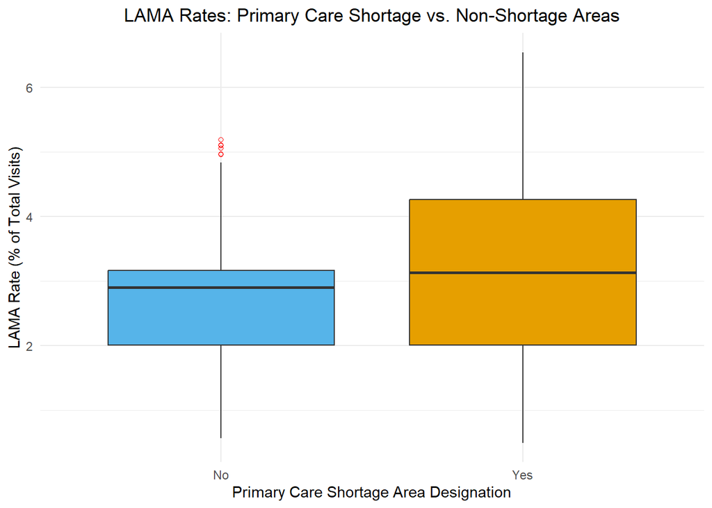

This boxplot compares leaving against medical advice (LAMA) rates by areas with a shortage in primary care and areas without a shortage. Although the median LAMA rate is similar for both groups, the rate for areas without a primary care shortage appears to be skewed toward higher LAMA rates, meaning that most EDs generally have lower LAMA rates, while there are a few high outliers. In contrast, in areas with a primary care shortage, the distribution is relatively symmetrical, meaning there are a considerable number of EDs here with higher LAMA rates than in areas without a primary care shortage.

The decision to leave an emergency department prematurely against a physician’s wishes can stem from a variety of reasons. One of the most common reasons I observed was that the wait time was simply too long, resulting in dissatisfaction with timeliness of care. High patient volume during especially busy hours, the long wait time for lab results to return, or infrequency of being seen by a physician were common points of frustration for patients.

In the UVA Emergency Department, I commonly worked shifts in an area of the ED called Rapid Medical Evaluation (RME). Here, patients who were triaged with relatively low acuity conditions were evaluated quickly, with the goal to dispo (give a patient a disposition, such as being discharged home, admitted, etc.) as efficiently as possible. We often had a high throughput of patients in this area, and among them, I noticed many were Spanish speakers, which led me to investigate this trend more.

# Emergency Department Presentation by Race

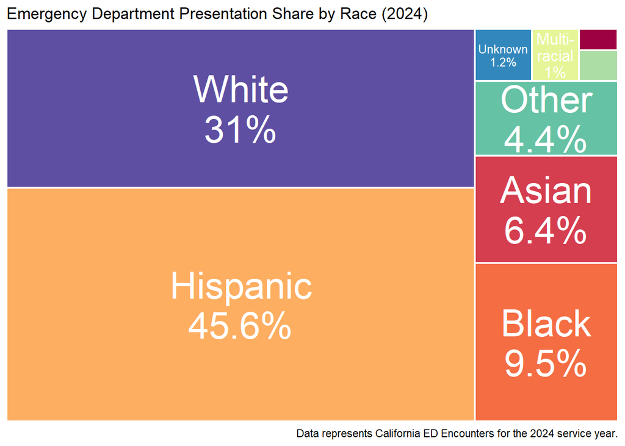

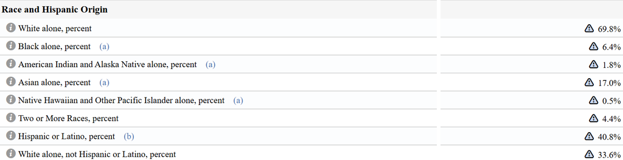

Census data from United States Census Bureau, 2024

This treemap of California Emergency Department Presentation shows that of all patients in 2024, Hispanic patients comprised 45.6% of all presentations, White patients comprised 31%, and so on. According to Census data for California in 2024, Hispanic individuals make up only 40.8% of the population. Also of note, 9.5% of all ED presentations in 2024 were Black patients, while they only make up 6.4% of the population. Why then, do Hispanic and Black individuals in particular present to emergency departments at disproportionately higher rates than their White and Asian counterparts, and what might account for this difference?

# Health Equity in Emergency Departments

This Shinyapp allows you to explore the relationship between outcomes/disposition (mortality, left against medical advice, admitted to acute care, etc.) by race group as a percentage of county’s population.

[interactive chart not shown]

To further explore the discrepancy between population composition and emergency department presentations, we can create a few scatterplots to see key relationships between LAMA rates and racial group. Of particular interest is the scatterplot with Hispanic patient presentation vs. Leaving Against Medical Advice (LAMA) rate, with a notably positive trend line, whereas other racial groups tend to have zero or negative trend lines. In other words, as the percentage of the Hispanic patient ED encounters increases, the rate of LAMA rate also increases. Although this may at first suggest a stronger dissatisfaction with care from Hispanic patients, this trend actually reveals a deeper issue of lack of access to primary care.

# Healthcare Expense Coverage in California Emergency Departments

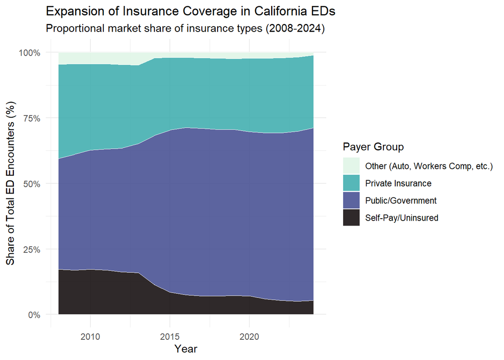

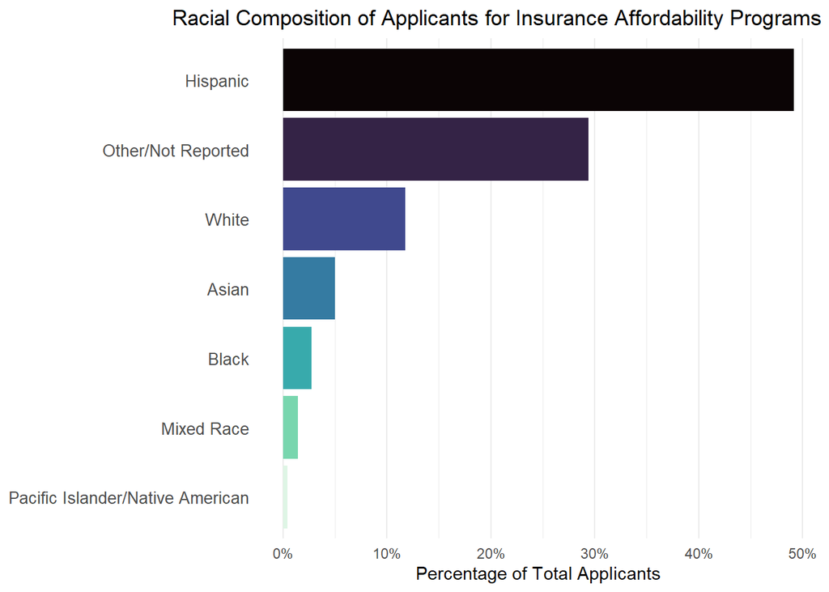

This is reflected by the higher LAMA rates for Hispanic patients. Since they are less likely to be insured, rates of utilizing primary care are lower. Visiting the emergency department for a benign chief complaint becomes a relatively cost-effective way to be seen by a physician quickly. However, the expensive costs of recommended laboratory tests during an ED visit precipitates leaving against medical advice to avoid financially debilitating costs.

Thankfully, the federal government has been addressing this disparity in healthcare access over the past decade. For the Hispanic population, who were the most likely to be uninsured when the Affordable Care Act (ACA) was enacted, the expansion of Medicaid was a primary driver in their uninsured rate dropping from 33% in 2010 to 21% by 2015. In major expansion states like California, Hispanic individuals have accounted for over 40% of the newly eligible population, which has helped lower financial barriers and improve access to primary care for a group often concentrated in low-wage sectors that do not offer employer-based insurance.

# Conclusions and Final Thoughts

The data from California’s emergency departments from 2008 to 2024 offers more than just a snapshot of hospital volume; it serves as a diagnostic tool for the health of our broader social and economic systems. By examining who walks through the ED doors and, perhaps more tellingly, who walks out prematurely, we uncover a narrative of persistent disparity across gender and race lines.

The consistent trend of higher ED utilization among women, even amidst a global pandemic, highlights a complex interplay between biology and healthcare experience. While women present more frequently, national survey data suggests they often do so within a system that provides a lower perceived quality of care, particularly regarding the clarity of test results and timeliness. This creates a paradoxical cycle: women may return to the ED more often to seek the answers they didn’t receive the first time, while men, perhaps driven by traditional roles as primary financial providers, are more likely to leave against medical advice (LAMA) when the “opportunity cost” of waiting becomes too high.

Ultimately, the high prevalence of hypertension and cardiac-related presentations underscores a universal health crisis, but the way these patients are treated and their ability to stay for care is not universal. From the trucker concerned about the price of an X-ray to the Spanish-speaking patients in RME, these data points represent real individuals navigating a system where financial stability is often a prerequisite for healthcare.

By identifying these trends, such as the expansion of government-funded coverage and the persisting disparities in primary care access, we can move toward a healthcare model that prioritizes equity over volume. The ED will always be a place where lives are saved, but it should not have to be the only place a patient feels they can be seen by a physician.

# References

- **Journal of Clinical Medicine:** [Rising Hypertension Rates and Cardiovascular Risk](https://pmc.ncbi.nlm.nih.gov/articles/PMC7998524/)
- **CDC:** [High Blood Pressure Facts and Statistics](https://www.cdc.gov/high-blood-pressure/data-research/facts-stats/index.html)
- **U.S. Census Bureau:** [QuickFacts: California Population Estimates (2024)](https://www.census.gov/quickfacts/fact/table/CA/PST045224)
- **MACPAC:** [Access in Brief: Medical Care Experiences by Race and Ethnicity](https://www.macpac.gov/publication/access-in-brief-experiences-in-accessing-medical-care-by-race-and-ethnicity/)
- **NCBI:** [Gender Disparities in Emergency Department Patient Experience](https://pmc.ncbi.nlm.nih.gov/articles/PMC8858357/)
- **NCBI:** [Barriers to Primary Care for Men and Impact on ED Utilization](https://pmc.ncbi.nlm.nih.gov/articles/PMC7337231/)
- **Congressional Research Service:** [Hispanic Population Trends and Medicaid Expansion](https://www.congress.gov/crs-product/IF10399)

# Data Sources

- **California Health and Human Services (CHHS):** [Ethnicity of Applicants for Insurance Affordability Programs](https://catalog.data.gov/dataset/ethnicity-of-applicants-for-insurance-affordability-programs)
- **Department of Health Care Access and Information (HCAI):** [Emergency Department Volume and Capacity (2021-2023)](https://catalog.data.gov/dataset/emergency-department-volume-and-capacity)
- **HCAI via Data.gov:** [Hospital ED Characteristics: Disposition, Race, Sex, and Payer by County](https://catalog.data.gov/dataset/hospital-emergency-department-characteristics-by-patient-county-of-residence)